# Risk Factor Analysis

## Outcome Variable

**Outcome Variable:** ever_wasted

## Predictor Variables

**Intervention Variable:** born_stunted

**Adjustment Set:**

- arm
- sex
- W_mage
- meducyrs
- feducyrs
- hhwealth_quart
- vagbrth
- W_nrooms
- month
- brthmon
- W_parity
- impfloor
- impsan
- delta_W_mage
- delta_meducyrs
- delta_feducyrs
- delta_hhwealth_quart
- delta_vagbrth
- delta_W_nrooms
- delta_month
- delta_brthmon
- delta_W_parity
- delta_impfloor
- delta_impsan

## Stratifying Variables

The analysis was stratified on these variable(s):

- agecat
- studyid
- country

## Data Summary

| agecat | studyid | country | born_stunted | ever_wasted | n_cell | n |
| --- | --- | --- | --- | --- | --- | --- |
| 0-3 months | ki0047075b-MAL-ED | BANGLADESH | 0 | 0 | 205 | 244 |
| 0-3 months | ki0047075b-MAL-ED | BANGLADESH | 0 | 1 | 7 | 244 |
| 0-3 months | ki0047075b-MAL-ED | BANGLADESH | 1 | 0 | 30 | 244 |
| 0-3 months | ki0047075b-MAL-ED | BANGLADESH | 1 | 1 | 2 | 244 |
| 0-3 months | ki0047075b-MAL-ED | BRAZIL | 0 | 0 | 163 | 183 |
| 0-3 months | ki0047075b-MAL-ED | BRAZIL | 0 | 1 | 6 | 183 |
| 0-3 months | ki0047075b-MAL-ED | BRAZIL | 1 | 0 | 14 | 183 |
| 0-3 months | ki0047075b-MAL-ED | BRAZIL | 1 | 1 | 0 | 183 |
| 0-3 months | ki0047075b-MAL-ED | INDIA | 0 | 0 | 154 | 204 |
| 0-3 months | ki0047075b-MAL-ED | INDIA | 0 | 1 | 20 | 204 |
| 0-3 months | ki0047075b-MAL-ED | INDIA | 1 | 0 | 29 | 204 |
| 0-3 months | ki0047075b-MAL-ED | INDIA | 1 | 1 | 1 | 204 |
| 0-3 months | ki0047075b-MAL-ED | NEPAL | 0 | 0 | 150 | 168 |
| 0-3 months | ki0047075b-MAL-ED | NEPAL | 0 | 1 | 4 | 168 |
| 0-3 months | ki0047075b-MAL-ED | NEPAL | 1 | 0 | 13 | 168 |
| 0-3 months | ki0047075b-MAL-ED | NEPAL | 1 | 1 | 1 | 168 |
| 0-3 months | ki0047075b-MAL-ED | PERU | 0 | 0 | 254 | 282 |
| 0-3 months | ki0047075b-MAL-ED | PERU | 0 | 1 | 2 | 282 |
| 0-3 months | ki0047075b-MAL-ED | PERU | 1 | 0 | 26 | 282 |
| 0-3 months | ki0047075b-MAL-ED | PERU | 1 | 1 | 0 | 282 |
| 0-3 months | ki0047075b-MAL-ED | SOUTH AFRICA | 0 | 0 | 226 | 258 |
| 0-3 months | ki0047075b-MAL-ED | SOUTH AFRICA | 0 | 1 | 6 | 258 |
| 0-3 months | ki0047075b-MAL-ED | SOUTH AFRICA | 1 | 0 | 26 | 258 |
| 0-3 months | ki0047075b-MAL-ED | SOUTH AFRICA | 1 | 1 | 0 | 258 |
| 0-3 months | ki0047075b-MAL-ED | TANZANIA, UNITED REPUBLIC OF | 0 | 0 | 127 | 145 |
| 0-3 months | ki0047075b-MAL-ED | TANZANIA, UNITED REPUBLIC OF | 0 | 1 | 1 | 145 |
| 0-3 months | ki0047075b-MAL-ED | TANZANIA, UNITED REPUBLIC OF | 1 | 0 | 17 | 145 |
| 0-3 months | ki0047075b-MAL-ED | TANZANIA, UNITED REPUBLIC OF | 1 | 1 | 0 | 145 |
| 0-3 months | ki1000108-CMC-V-BCS-2002 | INDIA | 0 | 0 | 44 | 84 |
| 0-3 months | ki1000108-CMC-V-BCS-2002 | INDIA | 0 | 1 | 29 | 84 |

[output cut: 410 more lines]

The following strata were considered:

- agecat: 0-3 months, studyid: ki0047075b-MAL-ED, country: BANGLADESH
- agecat: 0-3 months, studyid: ki0047075b-MAL-ED, country: BRAZIL
- agecat: 0-3 months, studyid: ki0047075b-MAL-ED, country: INDIA
- agecat: 0-3 months, studyid: ki0047075b-MAL-ED, country: NEPAL
- agecat: 0-3 months, studyid: ki0047075b-MAL-ED, country: PERU
- agecat: 0-3 months, studyid: ki0047075b-MAL-ED, country: SOUTH AFRICA
- agecat: 0-3 months, studyid: ki0047075b-MAL-ED, country: TANZANIA, UNITED REPUBLIC OF
- agecat: 0-3 months, studyid: ki1000108-CMC-V-BCS-2002, country: INDIA
- agecat: 0-3 months, studyid: ki1000108-IRC, country: INDIA
- agecat: 0-3 months, studyid: ki1000109-EE, country: PAKISTAN
- agecat: 0-3 months, studyid: ki1000109-ResPak, country: PAKISTAN
- agecat: 0-3 months, studyid: ki1000304b-SAS-CompFeed, country: INDIA
- agecat: 0-3 months, studyid: ki1017093-NIH-Birth, country: BANGLADESH
- agecat: 0-3 months, studyid: ki1017093b-PROVIDE, country: BANGLADESH
- agecat: 0-3 months, studyid: ki1017093c-NIH-Crypto, country: BANGLADESH
- agecat: 0-3 months, studyid: ki1101329-Keneba, country: GAMBIA
- agecat: 0-3 months, studyid: ki1114097-CMIN, country: BANGLADESH
- agecat: 0-3 months, studyid: ki1114097-CMIN, country: BRAZIL
- agecat: 0-3 months, studyid: ki1114097-CMIN, country: GUINEA-BISSAU
- agecat: 0-3 months, studyid: ki1114097-CMIN, country: PERU
- agecat: 0-3 months, studyid: ki1114097-CONTENT, country: PERU
- agecat: 0-3 months, studyid: ki1119695-PROBIT, country: BELARUS
- agecat: 0-3 months, studyid: ki1126311-ZVITAMBO, country: ZIMBABWE
- agecat: 0-3 months, studyid: ki1135781-COHORTS, country: GUATEMALA
- agecat: 0-3 months, studyid: ki1135781-COHORTS, country: INDIA
- agecat: 0-3 months, studyid: ki1135781-COHORTS, country: PHILIPPINES
- agecat: 0-3 months, studyid: kiGH5241-JiVitA-3, country: BANGLADESH
- agecat: 0-3 months, studyid: kiGH5241-JiVitA-4, country: BANGLADESH
- agecat: 12-24 months, studyid: ki0047075b-MAL-ED, country: BANGLADESH
- agecat: 12-24 months, studyid: ki0047075b-MAL-ED, country: BRAZIL
- agecat: 12-24 months, studyid: ki0047075b-MAL-ED, country: INDIA
- agecat: 12-24 months, studyid: ki0047075b-MAL-ED, country: NEPAL
- agecat: 12-24 months, studyid: ki0047075b-MAL-ED, country: PERU
- agecat: 12-24 months, studyid: ki0047075b-MAL-ED, country: SOUTH AFRICA
- agecat: 12-24 months, studyid: ki0047075b-MAL-ED, country: TANZANIA, UNITED REPUBLIC OF
- agecat: 12-24 months, studyid: ki1000108-CMC-V-BCS-2002, country: INDIA
- agecat: 12-24 months, studyid: ki1000108-IRC, country: INDIA
- agecat: 12-24 months, studyid: ki1000109-EE, country: PAKISTAN
- agecat: 12-24 months, studyid: ki1000109-ResPak, country: PAKISTAN
- agecat: 12-24 months, studyid: ki1000304b-SAS-CompFeed, country: INDIA
- agecat: 12-24 months, studyid: ki1017093-NIH-Birth, country: BANGLADESH
- agecat: 12-24 months, studyid: ki1017093b-PROVIDE, country: BANGLADESH
- agecat: 12-24 months, studyid: ki1017093c-NIH-Crypto, country: BANGLADESH
- agecat: 12-24 months, studyid: ki1101329-Keneba, country: GAMBIA
- agecat: 12-24 months, studyid: ki1114097-CMIN, country: BANGLADESH
- agecat: 12-24 months, studyid: ki1114097-CMIN, country: BRAZIL
- agecat: 12-24 months, studyid: ki1114097-CMIN, country: GUINEA-BISSAU
- agecat: 12-24 months, studyid: ki1114097-CMIN, country: PERU
- agecat: 12-24 months, studyid: ki1114097-CONTENT, country: PERU
- agecat: 12-24 months, studyid: ki1119695-PROBIT, country: BELARUS
- agecat: 12-24 months, studyid: ki1126311-ZVITAMBO, country: ZIMBABWE
- agecat: 12-24 months, studyid: ki1135781-COHORTS, country: GUATEMALA
- agecat: 12-24 months, studyid: ki1135781-COHORTS, country: PHILIPPINES
- agecat: 12-24 months, studyid: kiGH5241-JiVitA-3, country: BANGLADESH
- agecat: 12-24 months, studyid: kiGH5241-JiVitA-4, country: BANGLADESH
- agecat: 3-6 months, studyid: ki0047075b-MAL-ED, country: BANGLADESH
- agecat: 3-6 months, studyid: ki0047075b-MAL-ED, country: BRAZIL
- agecat: 3-6 months, studyid: ki0047075b-MAL-ED, country: INDIA
- agecat: 3-6 months, studyid: ki0047075b-MAL-ED, country: NEPAL
- agecat: 3-6 months, studyid: ki0047075b-MAL-ED, country: PERU
- agecat: 3-6 months, studyid: ki0047075b-MAL-ED, country: SOUTH AFRICA
- agecat: 3-6 months, studyid: ki0047075b-MAL-ED, country: TANZANIA, UNITED REPUBLIC OF
- agecat: 3-6 months, studyid: ki1000108-CMC-V-BCS-2002, country: INDIA
- agecat: 3-6 months, studyid: ki1000108-IRC, country: INDIA
- agecat: 3-6 months, studyid: ki1000109-EE, country: PAKISTAN
- agecat: 3-6 months, studyid: ki1000109-ResPak, country: PAKISTAN
- agecat: 3-6 months, studyid: ki1000304b-SAS-CompFeed, country: INDIA
- agecat: 3-6 months, studyid: ki1017093-NIH-Birth, country: BANGLADESH
- agecat: 3-6 months, studyid: ki1017093b-PROVIDE, country: BANGLADESH
- agecat: 3-6 months, studyid: ki1017093c-NIH-Crypto, country: BANGLADESH
- agecat: 3-6 months, studyid: ki1101329-Keneba, country: GAMBIA
- agecat: 3-6 months, studyid: ki1114097-CMIN, country: BANGLADESH
- agecat: 3-6 months, studyid: ki1114097-CMIN, country: BRAZIL
- agecat: 3-6 months, studyid: ki1114097-CMIN, country: GUINEA-BISSAU
- agecat: 3-6 months, studyid: ki1114097-CMIN, country: PERU
- agecat: 3-6 months, studyid: ki1114097-CONTENT, country: PERU
- agecat: 3-6 months, studyid: ki1119695-PROBIT, country: BELARUS
- agecat: 3-6 months, studyid: ki1126311-ZVITAMBO, country: ZIMBABWE
- agecat: 3-6 months, studyid: ki1135781-COHORTS, country: GUATEMALA
- agecat: 3-6 months, studyid: ki1135781-COHORTS, country: PHILIPPINES
- agecat: 3-6 months, studyid: kiGH5241-JiVitA-3, country: BANGLADESH
- agecat: 3-6 months, studyid: kiGH5241-JiVitA-4, country: BANGLADESH
- agecat: 6-12 months, studyid: ki0047075b-MAL-ED, country: BANGLADESH
- agecat: 6-12 months, studyid: ki0047075b-MAL-ED, country: BRAZIL
- agecat: 6-12 months, studyid: ki0047075b-MAL-ED, country: INDIA
- agecat: 6-12 months, studyid: ki0047075b-MAL-ED, country: NEPAL
- agecat: 6-12 months, studyid: ki0047075b-MAL-ED, country: PERU
- agecat: 6-12 months, studyid: ki0047075b-MAL-ED, country: SOUTH AFRICA
- agecat: 6-12 months, studyid: ki0047075b-MAL-ED, country: TANZANIA, UNITED REPUBLIC OF
- agecat: 6-12 months, studyid: ki1000108-CMC-V-BCS-2002, country: INDIA
- agecat: 6-12 months, studyid: ki1000108-IRC, country: INDIA
- agecat: 6-12 months, studyid: ki1000109-EE, country: PAKISTAN
- agecat: 6-12 months, studyid: ki1000109-ResPak, country: PAKISTAN
- agecat: 6-12 months, studyid: ki1000304b-SAS-CompFeed, country: INDIA
- agecat: 6-12 months, studyid: ki1017093-NIH-Birth, country: BANGLADESH
- agecat: 6-12 months, studyid: ki1017093b-PROVIDE, country: BANGLADESH
- agecat: 6-12 months, studyid: ki1017093c-NIH-Crypto, country: BANGLADESH
- agecat: 6-12 months, studyid: ki1101329-Keneba, country: GAMBIA
- agecat: 6-12 months, studyid: ki1114097-CMIN, country: BANGLADESH
- agecat: 6-12 months, studyid: ki1114097-CMIN, country: BRAZIL
- agecat: 6-12 months, studyid: ki1114097-CMIN, country: GUINEA-BISSAU
- agecat: 6-12 months, studyid: ki1114097-CMIN, country: PERU
- agecat: 6-12 months, studyid: ki1114097-CONTENT, country: PERU
- agecat: 6-12 months, studyid: ki1119695-PROBIT, country: BELARUS
- agecat: 6-12 months, studyid: ki1126311-ZVITAMBO, country: ZIMBABWE
- agecat: 6-12 months, studyid: ki1135781-COHORTS, country: GUATEMALA
- agecat: 6-12 months, studyid: ki1135781-COHORTS, country: INDIA
- agecat: 6-12 months, studyid: ki1135781-COHORTS, country: PHILIPPINES
- agecat: 6-12 months, studyid: kiGH5241-JiVitA-3, country: BANGLADESH
- agecat: 6-12 months, studyid: kiGH5241-JiVitA-4, country: BANGLADESH

### Dropped Strata

Some strata were dropped due to rare outcomes:

- agecat: 0-3 months, studyid: ki0047075b-MAL-ED, country: BANGLADESH
- agecat: 0-3 months, studyid: ki0047075b-MAL-ED, country: BRAZIL
- agecat: 0-3 months, studyid: ki0047075b-MAL-ED, country: INDIA
- agecat: 0-3 months, studyid: ki0047075b-MAL-ED, country: NEPAL
- agecat: 0-3 months, studyid: ki0047075b-MAL-ED, country: PERU
- agecat: 0-3 months, studyid: ki0047075b-MAL-ED, country: SOUTH AFRICA
- agecat: 0-3 months, studyid: ki0047075b-MAL-ED, country: TANZANIA, UNITED REPUBLIC OF
- agecat: 0-3 months, studyid: ki1000108-CMC-V-BCS-2002, country: INDIA
- agecat: 0-3 months, studyid: ki1000109-EE, country: PAKISTAN
- agecat: 0-3 months, studyid: ki1000109-ResPak, country: PAKISTAN
- agecat: 0-3 months, studyid: ki1017093-NIH-Birth, country: BANGLADESH
- agecat: 0-3 months, studyid: ki1017093b-PROVIDE, country: BANGLADESH
- agecat: 0-3 months, studyid: ki1017093c-NIH-Crypto, country: BANGLADESH
- agecat: 0-3 months, studyid: ki1114097-CMIN, country: BANGLADESH
- agecat: 0-3 months, studyid: ki1114097-CMIN, country: BRAZIL
- agecat: 0-3 months, studyid: ki1114097-CMIN, country: GUINEA-BISSAU
- agecat: 0-3 months, studyid: ki1114097-CMIN, country: PERU
- agecat: 0-3 months, studyid: ki1114097-CONTENT, country: PERU
- agecat: 0-3 months, studyid: ki1119695-PROBIT, country: BELARUS
- agecat: 0-3 months, studyid: ki1135781-COHORTS, country: GUATEMALA
- agecat: 0-3 months, studyid: ki1135781-COHORTS, country: PHILIPPINES
- agecat: 0-3 months, studyid: kiGH5241-JiVitA-4, country: BANGLADESH
- agecat: 3-6 months, studyid: ki0047075b-MAL-ED, country: BANGLADESH
- agecat: 3-6 months, studyid: ki0047075b-MAL-ED, country: BRAZIL
- agecat: 3-6 months, studyid: ki0047075b-MAL-ED, country: INDIA
- agecat: 3-6 months, studyid: ki0047075b-MAL-ED, country: NEPAL
- agecat: 3-6 months, studyid: ki0047075b-MAL-ED, country: PERU
- agecat: 3-6 months, studyid: ki0047075b-MAL-ED, country: SOUTH AFRICA
- agecat: 3-6 months, studyid: ki0047075b-MAL-ED, country: TANZANIA, UNITED REPUBLIC OF
- agecat: 3-6 months, studyid: ki1000108-CMC-V-BCS-2002, country: INDIA
- agecat: 3-6 months, studyid: ki1000108-IRC, country: INDIA
- agecat: 3-6 months, studyid: ki1000109-ResPak, country: PAKISTAN
- agecat: 3-6 months, studyid: ki1017093b-PROVIDE, country: BANGLADESH
- agecat: 3-6 months, studyid: ki1017093c-NIH-Crypto, country: BANGLADESH
- agecat: 3-6 months, studyid: ki1114097-CMIN, country: BANGLADESH
- agecat: 3-6 months, studyid: ki1114097-CMIN, country: BRAZIL
- agecat: 3-6 months, studyid: ki1114097-CMIN, country: GUINEA-BISSAU
- agecat: 3-6 months, studyid: ki1114097-CMIN, country: PERU
- agecat: 3-6 months, studyid: ki1114097-CONTENT, country: PERU
- agecat: 3-6 months, studyid: ki1119695-PROBIT, country: BELARUS
- agecat: 3-6 months, studyid: ki1135781-COHORTS, country: GUATEMALA
- agecat: 6-12 months, studyid: ki0047075b-MAL-ED, country: BANGLADESH
- agecat: 6-12 months, studyid: ki0047075b-MAL-ED, country: BRAZIL
- agecat: 6-12 months, studyid: ki0047075b-MAL-ED, country: INDIA
- agecat: 6-12 months, studyid: ki0047075b-MAL-ED, country: NEPAL
- agecat: 6-12 months, studyid: ki0047075b-MAL-ED, country: PERU
- agecat: 6-12 months, studyid: ki0047075b-MAL-ED, country: SOUTH AFRICA
- agecat: 6-12 months, studyid: ki0047075b-MAL-ED, country: TANZANIA, UNITED REPUBLIC OF
- agecat: 6-12 months, studyid: ki1000108-CMC-V-BCS-2002, country: INDIA
- agecat: 6-12 months, studyid: ki1000109-ResPak, country: PAKISTAN
- agecat: 6-12 months, studyid: ki1017093b-PROVIDE, country: BANGLADESH
- agecat: 6-12 months, studyid: ki1114097-CMIN, country: BANGLADESH
- agecat: 6-12 months, studyid: ki1114097-CMIN, country: BRAZIL
- agecat: 6-12 months, studyid: ki1114097-CMIN, country: GUINEA-BISSAU
- agecat: 6-12 months, studyid: ki1114097-CMIN, country: PERU
- agecat: 6-12 months, studyid: ki1114097-CONTENT, country: PERU
- agecat: 6-12 months, studyid: ki1119695-PROBIT, country: BELARUS
- agecat: 6-12 months, studyid: ki1135781-COHORTS, country: GUATEMALA
- agecat: 12-24 months, studyid: ki0047075b-MAL-ED, country: BANGLADESH
- agecat: 12-24 months, studyid: ki0047075b-MAL-ED, country: BRAZIL
- agecat: 12-24 months, studyid: ki0047075b-MAL-ED, country: NEPAL
- agecat: 12-24 months, studyid: ki0047075b-MAL-ED, country: SOUTH AFRICA
- agecat: 12-24 months, studyid: ki0047075b-MAL-ED, country: TANZANIA, UNITED REPUBLIC OF
- agecat: 12-24 months, studyid: ki1000108-CMC-V-BCS-2002, country: INDIA
- agecat: 12-24 months, studyid: ki1000109-ResPak, country: PAKISTAN
- agecat: 12-24 months, studyid: ki1017093b-PROVIDE, country: BANGLADESH
- agecat: 12-24 months, studyid: ki1017093c-NIH-Crypto, country: BANGLADESH
- agecat: 12-24 months, studyid: ki1114097-CMIN, country: BANGLADESH
- agecat: 12-24 months, studyid: ki1114097-CMIN, country: BRAZIL
- agecat: 12-24 months, studyid: ki1114097-CMIN, country: GUINEA-BISSAU
- agecat: 12-24 months, studyid: ki1114097-CMIN, country: PERU
- agecat: 12-24 months, studyid: ki1114097-CONTENT, country: PERU
- agecat: 12-24 months, studyid: ki1119695-PROBIT, country: BELARUS
- agecat: 12-24 months, studyid: ki1135781-COHORTS, country: GUATEMALA

## Methods Detail

We’re interested in the causal parameters $E[Y_a]$ for all values of $a \in \mathcal{A}$. These parameters represent the mean outcome if, possibly contrary to fact, we intervened to set all units to have $A=a$. Under the randomization and positivity assumptions, these are identified by the statistical parameters $\psi_a=E_W[E_{Y|A,W}(Y|A=a,W)]$. In addition, we’re interested in the mean of $Y$, $E[Y]$ under no intervention (the observed mean). We will estimate these parameters by using SuperLearner to fit the relevant likelihood factors – $E_{Y|A,W}(Y|A=a,W)$ and $p(A=a|W)$, and then updating our likelihood fit using a joint TMLE.

For unadjusted analyses ($W=\{\}$), initial likelihoods were estimated using Lrnr_glm to estimate the simple $E(Y|A)$ and Lrnr_mean to estimate $p(A)$. For adjusted analyses, a small library containing Lrnr_glmnet, Lrnr_xgboost, and Lrnr_mean was used.

Having estimated these parameters, we will then use the delta method to estimate relative risks and attributable risks relative to a prespecified baseline level of $A$.

# Results Detail

## Results Plots

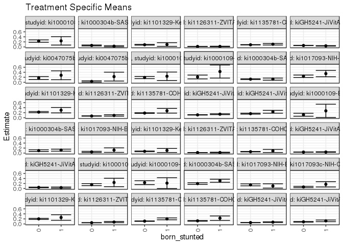

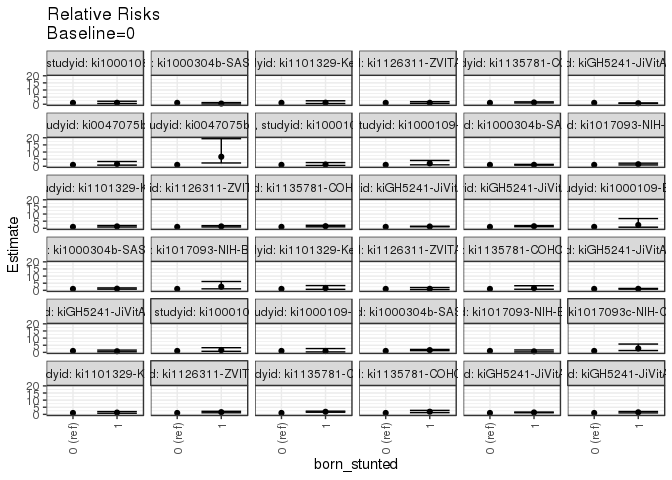

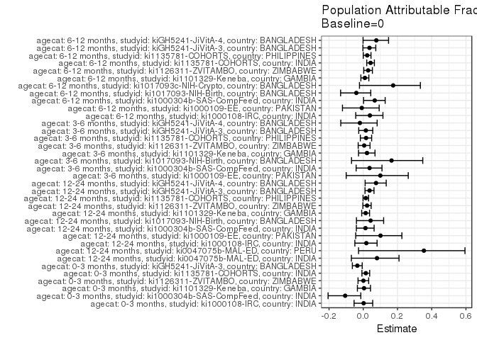

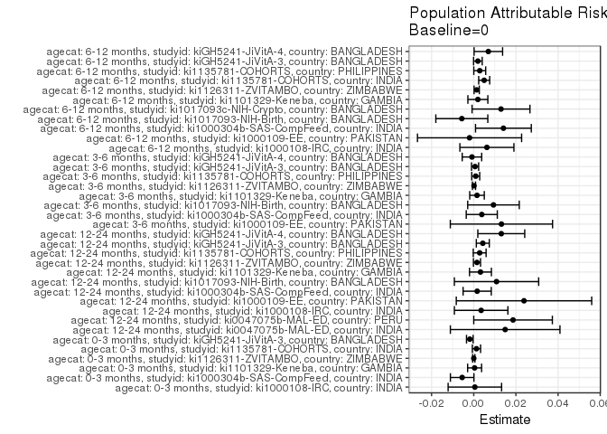

## Results Table

### Parameter: TSM

| agecat | studyid | country | intervention_level | baseline_level | estimate | ci_lower | ci_upper |
| --- | --- | --- | --- | --- | --- | --- | --- |
| 0-3 months | ki1000108-IRC | INDIA | 0 | NA | 0.2327044 | 0.1861938 | 0.2792150 |
| 0-3 months | ki1000108-IRC | INDIA | 1 | NA | 0.2400000 | 0.0723419 | 0.4076581 |
| 0-3 months | ki1000304b-SAS-CompFeed | INDIA | 0 | NA | 0.0574282 | 0.0399649 | 0.0748915 |
| 0-3 months | ki1000304b-SAS-CompFeed | INDIA | 1 | NA | 0.0276243 | 0.0062619 | 0.0489867 |
| 0-3 months | ki1101329-Keneba | GAMBIA | 0 | NA | 0.0860534 | 0.0710772 | 0.1010296 |
| 0-3 months | ki1101329-Keneba | GAMBIA | 1 | NA | 0.0952381 | 0.0227270 | 0.1677492 |
| 0-3 months | ki1126311-ZVITAMBO | ZIMBABWE | 0 | NA | 0.0171722 | 0.0148688 | 0.0194755 |
| 0-3 months | ki1126311-ZVITAMBO | ZIMBABWE | 1 | NA | 0.0178469 | 0.0081188 | 0.0275750 |
| 0-3 months | ki1135781-COHORTS | INDIA | 0 | NA | 0.0847728 | 0.0776105 | 0.0919350 |
| 0-3 months | ki1135781-COHORTS | INDIA | 1 | NA | 0.1055875 | 0.0747363 | 0.1364387 |
| 0-3 months | kiGH5241-JiVitA-3 | BANGLADESH | 0 | NA | 0.0557911 | 0.0513854 | 0.0601968 |
| 0-3 months | kiGH5241-JiVitA-3 | BANGLADESH | 1 | NA | 0.0412467 | 0.0333019 | 0.0491916 |
| 3-6 months | ki1000109-EE | PAKISTAN | 0 | NA | 0.1186441 | 0.0600713 | 0.1772168 |
| 3-6 months | ki1000109-EE | PAKISTAN | 1 | NA | 0.2727273 | 0.0085140 | 0.5369405 |
| 3-6 months | ki1000304b-SAS-CompFeed | INDIA | 0 | NA | 0.0996796 | 0.0660731 | 0.1332861 |
| 3-6 months | ki1000304b-SAS-CompFeed | INDIA | 1 | NA | 0.1164662 | 0.0771244 | 0.1558081 |
| 3-6 months | ki1017093-NIH-Birth | BANGLADESH | 0 | NA | 0.0473373 | 0.0246689 | 0.0700057 |
| 3-6 months | ki1017093-NIH-Birth | BANGLADESH | 1 | NA | 0.1200000 | 0.0298106 | 0.2101894 |
| 3-6 months | ki1101329-Keneba | GAMBIA | 0 | NA | 0.0699301 | 0.0559918 | 0.0838684 |
| 3-6 months | ki1101329-Keneba | GAMBIA | 1 | NA | 0.1071429 | 0.0261049 | 0.1881808 |
| 3-6 months | ki1126311-ZVITAMBO | ZIMBABWE | 0 | NA | 0.0216362 | 0.0184271 | 0.0248453 |
| 3-6 months | ki1126311-ZVITAMBO | ZIMBABWE | 1 | NA | 0.0227689 | 0.0086765 | 0.0368613 |
| 3-6 months | ki1135781-COHORTS | PHILIPPINES | 0 | NA | 0.0560278 | 0.0471659 | 0.0648898 |
| 3-6 months | ki1135781-COHORTS | PHILIPPINES | 1 | NA | 0.0875000 | 0.0255694 | 0.1494306 |
| 3-6 months | kiGH5241-JiVitA-3 | BANGLADESH | 0 | NA | 0.0406900 | 0.0364733 | 0.0449068 |
| 3-6 months | kiGH5241-JiVitA-3 | BANGLADESH | 1 | NA | 0.0430556 | 0.0339071 | 0.0522040 |
| 3-6 months | kiGH5241-JiVitA-4 | BANGLADESH | 0 | NA | 0.0443292 | 0.0321156 | 0.0565427 |
| 3-6 months | kiGH5241-JiVitA-4 | BANGLADESH | 1 | NA | 0.0349121 | 0.0116328 | 0.0581915 |
| 6-12 months | ki1000108-IRC | INDIA | 0 | NA | 0.1545741 | 0.1147212 | 0.1944271 |
| 6-12 months | ki1000108-IRC | INDIA | 1 | NA | 0.2400000 | 0.0723412 | 0.4076588 |
| 6-12 months | ki1000109-EE | PAKISTAN | 0 | NA | 0.2327586 | 0.1555591 | 0.3099582 |
| 6-12 months | ki1000109-EE | PAKISTAN | 1 | NA | 0.2142857 | -0.0014837 | 0.4300551 |
| 6-12 months | ki1000304b-SAS-CompFeed | INDIA | 0 | NA | 0.1959782 | 0.1622115 | 0.2297448 |
| 6-12 months | ki1000304b-SAS-CompFeed | INDIA | 1 | NA | 0.3088742 | 0.2478719 | 0.3698764 |
| 6-12 months | ki1017093-NIH-Birth | BANGLADESH | 0 | NA | 0.1450617 | 0.1066643 | 0.1834592 |
| 6-12 months | ki1017093-NIH-Birth | BANGLADESH | 1 | NA | 0.1020408 | 0.0171720 | 0.1869097 |
| 6-12 months | ki1017093c-NIH-Crypto | BANGLADESH | 0 | NA | 0.0610465 | 0.0357141 | 0.0863789 |
| 6-12 months | ki1017093c-NIH-Crypto | BANGLADESH | 1 | NA | 0.1666667 | 0.0611027 | 0.2722307 |
| 6-12 months | ki1101329-Keneba | GAMBIA | 0 | NA | 0.2013582 | 0.1793367 | 0.2233798 |
| 6-12 months | ki1101329-Keneba | GAMBIA | 1 | NA | 0.2556188 | 0.1452151 | 0.3660224 |
| 6-12 months | ki1126311-ZVITAMBO | ZIMBABWE | 0 | NA | 0.0476708 | 0.0432236 | 0.0521179 |
| 6-12 months | ki1126311-ZVITAMBO | ZIMBABWE | 1 | NA | 0.0746038 | 0.0513030 | 0.0979045 |
| 6-12 months | ki1135781-COHORTS | INDIA | 0 | NA | 0.1106155 | 0.1022813 | 0.1189496 |
| 6-12 months | ki1135781-COHORTS | INDIA | 1 | NA | 0.2018146 | 0.1642149 | 0.2394143 |
| 6-12 months | ki1135781-COHORTS | PHILIPPINES | 0 | NA | 0.1217701 | 0.1090637 | 0.1344766 |
| 6-12 months | ki1135781-COHORTS | PHILIPPINES | 1 | NA | 0.2280402 | 0.1398245 | 0.3162559 |
| 6-12 months | kiGH5241-JiVitA-3 | BANGLADESH | 0 | NA | 0.0521716 | 0.0474064 | 0.0569367 |
| 6-12 months | kiGH5241-JiVitA-3 | BANGLADESH | 1 | NA | 0.0704333 | 0.0587250 | 0.0821417 |
| 6-12 months | kiGH5241-JiVitA-4 | BANGLADESH | 0 | NA | 0.0838542 | 0.0690850 | 0.0986234 |
| 6-12 months | kiGH5241-JiVitA-4 | BANGLADESH | 1 | NA | 0.1218141 | 0.0876588 | 0.1559694 |
| 12-24 months | ki0047075b-MAL-ED | INDIA | 0 | NA | 0.1708861 | 0.1120329 | 0.2297392 |
| 12-24 months | ki0047075b-MAL-ED | INDIA | 1 | NA | 0.2800000 | 0.1035128 | 0.4564872 |
| 12-24 months | ki0047075b-MAL-ED | PERU | 0 | NA | 0.0339806 | 0.0091848 | 0.0587763 |
| 12-24 months | ki0047075b-MAL-ED | PERU | 1 | NA | 0.2272727 | 0.0517724 | 0.4027731 |
| 12-24 months | ki1000108-IRC | INDIA | 0 | NA | 0.1918239 | 0.1484855 | 0.2351623 |
| 12-24 months | ki1000108-IRC | INDIA | 1 | NA | 0.2400000 | 0.0723419 | 0.4076581 |
| 12-24 months | ki1000109-EE | PAKISTAN | 0 | NA | 0.2123879 | 0.1366783 | 0.2880975 |
| 12-24 months | ki1000109-EE | PAKISTAN | 1 | NA | 0.4285914 | 0.1685753 | 0.6886074 |
| 12-24 months | ki1000304b-SAS-CompFeed | INDIA | 0 | NA | 0.1245126 | 0.1097703 | 0.1392549 |
| 12-24 months | ki1000304b-SAS-CompFeed | INDIA | 1 | NA | 0.1268885 | 0.0852686 | 0.1685085 |
| 12-24 months | ki1017093-NIH-Birth | BANGLADESH | 0 | NA | 0.2406677 | 0.1915615 | 0.2897739 |
| 12-24 months | ki1017093-NIH-Birth | BANGLADESH | 1 | NA | 0.3465955 | 0.2204939 | 0.4726970 |
| 12-24 months | ki1101329-Keneba | GAMBIA | 0 | NA | 0.2229884 | 0.1997709 | 0.2462059 |
| 12-24 months | ki1101329-Keneba | GAMBIA | 1 | NA | 0.2985980 | 0.1897699 | 0.4074261 |
| 12-24 months | ki1126311-ZVITAMBO | ZIMBABWE | 0 | NA | 0.0675824 | 0.0614085 | 0.0737564 |
| 12-24 months | ki1126311-ZVITAMBO | ZIMBABWE | 1 | NA | 0.0901108 | 0.0619828 | 0.1182388 |
| 12-24 months | ki1135781-COHORTS | PHILIPPINES | 0 | NA | 0.1849077 | 0.1695868 | 0.2002287 |
| 12-24 months | ki1135781-COHORTS | PHILIPPINES | 1 | NA | 0.2767217 | 0.1832245 | 0.3702190 |
| 12-24 months | kiGH5241-JiVitA-3 | BANGLADESH | 0 | NA | 0.1124297 | 0.1051426 | 0.1197168 |
| 12-24 months | kiGH5241-JiVitA-3 | BANGLADESH | 1 | NA | 0.1406655 | 0.1229506 | 0.1583803 |
| 12-24 months | kiGH5241-JiVitA-4 | BANGLADESH | 0 | NA | 0.1620551 | 0.1436950 | 0.1804151 |
| 12-24 months | kiGH5241-JiVitA-4 | BANGLADESH | 1 | NA | 0.2358877 | 0.1796211 | 0.2921544 |

### Parameter: E(Y)

| agecat | studyid | country | intervention_level | baseline_level | estimate | ci_lower | ci_upper |
| --- | --- | --- | --- | --- | --- | --- | --- |
| 0-3 months | ki1000108-IRC | INDIA | NA | NA | 0.2332362 | 0.1884170 | 0.2780553 |
| 0-3 months | ki1000304b-SAS-CompFeed | INDIA | NA | NA | 0.0519348 | 0.0380636 | 0.0658060 |
| 0-3 months | ki1101329-Keneba | GAMBIA | NA | NA | 0.0864635 | 0.0717939 | 0.1011331 |
| 0-3 months | ki1126311-ZVITAMBO | ZIMBABWE | NA | NA | 0.0171893 | 0.0149476 | 0.0194310 |
| 0-3 months | ki1135781-COHORTS | INDIA | NA | NA | 0.0860649 | 0.0790793 | 0.0930505 |
| 0-3 months | kiGH5241-JiVitA-3 | BANGLADESH | NA | NA | 0.0539269 | 0.0499950 | 0.0578587 |
| 3-6 months | ki1000109-EE | PAKISTAN | NA | NA | 0.1317829 | 0.0731844 | 0.1903815 |
| 3-6 months | ki1000304b-SAS-CompFeed | INDIA | NA | NA | 0.1034913 | 0.0730456 | 0.1339370 |
| 3-6 months | ki1017093-NIH-Birth | BANGLADESH | NA | NA | 0.0567010 | 0.0336594 | 0.0797426 |
| 3-6 months | ki1101329-Keneba | GAMBIA | NA | NA | 0.0714818 | 0.0576981 | 0.0852654 |
| 3-6 months | ki1126311-ZVITAMBO | ZIMBABWE | NA | NA | 0.0217574 | 0.0186222 | 0.0248926 |
| 3-6 months | ki1135781-COHORTS | PHILIPPINES | NA | NA | 0.0569715 | 0.0481747 | 0.0657684 |
| 3-6 months | kiGH5241-JiVitA-3 | BANGLADESH | NA | NA | 0.0413243 | 0.0374983 | 0.0451502 |
| 3-6 months | kiGH5241-JiVitA-4 | BANGLADESH | NA | NA | 0.0434783 | 0.0324169 | 0.0545396 |
| 6-12 months | ki1000108-IRC | INDIA | NA | NA | 0.1608187 | 0.1218275 | 0.1998100 |
| 6-12 months | ki1000109-EE | PAKISTAN | NA | NA | 0.2307692 | 0.1580632 | 0.3034753 |
| 6-12 months | ki1000304b-SAS-CompFeed | INDIA | NA | NA | 0.2100559 | 0.1780909 | 0.2420208 |
| 6-12 months | ki1017093-NIH-Birth | BANGLADESH | NA | NA | 0.1394102 | 0.1042119 | 0.1746085 |
| 6-12 months | ki1017093c-NIH-Crypto | BANGLADESH | NA | NA | 0.0739796 | 0.0480362 | 0.0999229 |
| 6-12 months | ki1101329-Keneba | GAMBIA | NA | NA | 0.2033133 | 0.1816592 | 0.2249673 |
| 6-12 months | ki1126311-ZVITAMBO | ZIMBABWE | NA | NA | 0.0490692 | 0.0446771 | 0.0534613 |
| 6-12 months | ki1135781-COHORTS | INDIA | NA | NA | 0.1155709 | 0.1073281 | 0.1238138 |
| 6-12 months | ki1135781-COHORTS | PHILIPPINES | NA | NA | 0.1246189 | 0.1119791 | 0.1372587 |
| 6-12 months | kiGH5241-JiVitA-3 | BANGLADESH | NA | NA | 0.0541387 | 0.0496481 | 0.0586293 |
| 6-12 months | kiGH5241-JiVitA-4 | BANGLADESH | NA | NA | 0.0907828 | 0.0771434 | 0.1044222 |
| 12-24 months | ki0047075b-MAL-ED | INDIA | NA | NA | 0.1857923 | 0.1292864 | 0.2422983 |
| 12-24 months | ki0047075b-MAL-ED | PERU | NA | NA | 0.0526316 | 0.0235835 | 0.0816797 |
| 12-24 months | ki1000108-IRC | INDIA | NA | NA | 0.1953353 | 0.1533175 | 0.2373530 |
| 12-24 months | ki1000109-EE | PAKISTAN | NA | NA | 0.2362205 | 0.1620543 | 0.3103866 |
| 12-24 months | ki1000304b-SAS-CompFeed | INDIA | NA | NA | 0.1261468 | 0.1083153 | 0.1439783 |
| 12-24 months | ki1017093-NIH-Birth | BANGLADESH | NA | NA | 0.2514793 | 0.2051574 | 0.2978012 |
| 12-24 months | ki1101329-Keneba | GAMBIA | NA | NA | 0.2261813 | 0.2033515 | 0.2490110 |
| 12-24 months | ki1126311-ZVITAMBO | ZIMBABWE | NA | NA | 0.0691196 | 0.0630513 | 0.0751880 |
| 12-24 months | ki1135781-COHORTS | PHILIPPINES | NA | NA | 0.1877214 | 0.1725355 | 0.2029073 |
| 12-24 months | kiGH5241-JiVitA-3 | BANGLADESH | NA | NA | 0.1167292 | 0.1098289 | 0.1236294 |
| 12-24 months | kiGH5241-JiVitA-4 | BANGLADESH | NA | NA | 0.1751174 | 0.1566212 | 0.1936135 |

### Parameter: RR

| agecat | studyid | country | intervention_level | baseline_level | estimate | ci_lower | ci_upper |
| --- | --- | --- | --- | --- | --- | --- | --- |
| 0-3 months | ki1000108-IRC | INDIA | 0 | 0 | 1.0000000 | 1.0000000 | 1.0000000 |
| 0-3 months | ki1000108-IRC | INDIA | 1 | 0 | 1.0313514 | 0.4987075 | 2.1328848 |
| 0-3 months | ki1000304b-SAS-CompFeed | INDIA | 0 | 0 | 1.0000000 | 1.0000000 | 1.0000000 |
| 0-3 months | ki1000304b-SAS-CompFeed | INDIA | 1 | 0 | 0.4810233 | 0.1947040 | 1.1883857 |
| 0-3 months | ki1101329-Keneba | GAMBIA | 0 | 0 | 1.0000000 | 1.0000000 | 1.0000000 |
| 0-3 months | ki1101329-Keneba | GAMBIA | 1 | 0 | 1.1067323 | 0.5068240 | 2.4167294 |
| 0-3 months | ki1126311-ZVITAMBO | ZIMBABWE | 0 | 0 | 1.0000000 | 1.0000000 | 1.0000000 |
| 0-3 months | ki1126311-ZVITAMBO | ZIMBABWE | 1 | 0 | 1.0392913 | 0.5928814 | 1.8218255 |
| 0-3 months | ki1135781-COHORTS | INDIA | 0 | 0 | 1.0000000 | 1.0000000 | 1.0000000 |
| 0-3 months | ki1135781-COHORTS | INDIA | 1 | 0 | 1.2455352 | 0.9188858 | 1.6883034 |
| 0-3 months | kiGH5241-JiVitA-3 | BANGLADESH | 0 | 0 | 1.0000000 | 1.0000000 | 1.0000000 |
| 0-3 months | kiGH5241-JiVitA-3 | BANGLADESH | 1 | 0 | 0.7393069 | 0.6003080 | 0.9104906 |
| 3-6 months | ki1000109-EE | PAKISTAN | 0 | 0 | 1.0000000 | 1.0000000 | 1.0000000 |
| 3-6 months | ki1000109-EE | PAKISTAN | 1 | 0 | 2.2987013 | 0.7749361 | 6.8186628 |
| 3-6 months | ki1000304b-SAS-CompFeed | INDIA | 0 | 0 | 1.0000000 | 1.0000000 | 1.0000000 |
| 3-6 months | ki1000304b-SAS-CompFeed | INDIA | 1 | 0 | 1.1684060 | 0.8123275 | 1.6805691 |
| 3-6 months | ki1017093-NIH-Birth | BANGLADESH | 0 | 0 | 1.0000000 | 1.0000000 | 1.0000000 |
| 3-6 months | ki1017093-NIH-Birth | BANGLADESH | 1 | 0 | 2.5350000 | 1.0397934 | 6.1802899 |
| 3-6 months | ki1101329-Keneba | GAMBIA | 0 | 0 | 1.0000000 | 1.0000000 | 1.0000000 |
| 3-6 months | ki1101329-Keneba | GAMBIA | 1 | 0 | 1.5321429 | 0.7008169 | 3.3496079 |
| 3-6 months | ki1126311-ZVITAMBO | ZIMBABWE | 0 | 0 | 1.0000000 | 1.0000000 | 1.0000000 |
| 3-6 months | ki1126311-ZVITAMBO | ZIMBABWE | 1 | 0 | 1.0523535 | 0.5568802 | 1.9886643 |
| 3-6 months | ki1135781-COHORTS | PHILIPPINES | 0 | 0 | 1.0000000 | 1.0000000 | 1.0000000 |
| 3-6 months | ki1135781-COHORTS | PHILIPPINES | 1 | 0 | 1.5617241 | 0.7562029 | 3.2253014 |
| 3-6 months | kiGH5241-JiVitA-3 | BANGLADESH | 0 | 0 | 1.0000000 | 1.0000000 | 1.0000000 |
| 3-6 months | kiGH5241-JiVitA-3 | BANGLADESH | 1 | 0 | 1.0581352 | 0.8337249 | 1.3429490 |
| 3-6 months | kiGH5241-JiVitA-4 | BANGLADESH | 0 | 0 | 1.0000000 | 1.0000000 | 1.0000000 |
| 3-6 months | kiGH5241-JiVitA-4 | BANGLADESH | 1 | 0 | 0.7875657 | 0.3884574 | 1.5967249 |
| 6-12 months | ki1000108-IRC | INDIA | 0 | 0 | 1.0000000 | 1.0000000 | 1.0000000 |
| 6-12 months | ki1000108-IRC | INDIA | 1 | 0 | 1.5526531 | 0.7373649 | 3.2693874 |
| 6-12 months | ki1000109-EE | PAKISTAN | 0 | 0 | 1.0000000 | 1.0000000 | 1.0000000 |
| 6-12 months | ki1000109-EE | PAKISTAN | 1 | 0 | 0.9206349 | 0.3189139 | 2.6576724 |
| 6-12 months | ki1000304b-SAS-CompFeed | INDIA | 0 | 0 | 1.0000000 | 1.0000000 | 1.0000000 |
| 6-12 months | ki1000304b-SAS-CompFeed | INDIA | 1 | 0 | 1.5760640 | 1.2111938 | 2.0508509 |
| 6-12 months | ki1017093-NIH-Birth | BANGLADESH | 0 | 0 | 1.0000000 | 1.0000000 | 1.0000000 |
| 6-12 months | ki1017093-NIH-Birth | BANGLADESH | 1 | 0 | 0.7034303 | 0.2938735 | 1.6837661 |
| 6-12 months | ki1017093c-NIH-Crypto | BANGLADESH | 0 | 0 | 1.0000000 | 1.0000000 | 1.0000000 |
| 6-12 months | ki1017093c-NIH-Crypto | BANGLADESH | 1 | 0 | 2.7301587 | 1.2803647 | 5.8215965 |
| 6-12 months | ki1101329-Keneba | GAMBIA | 0 | 0 | 1.0000000 | 1.0000000 | 1.0000000 |
| 6-12 months | ki1101329-Keneba | GAMBIA | 1 | 0 | 1.2694725 | 0.8132380 | 1.9816591 |
| 6-12 months | ki1126311-ZVITAMBO | ZIMBABWE | 0 | 0 | 1.0000000 | 1.0000000 | 1.0000000 |
| 6-12 months | ki1126311-ZVITAMBO | ZIMBABWE | 1 | 0 | 1.5649797 | 1.1298162 | 2.1677520 |
| 6-12 months | ki1135781-COHORTS | INDIA | 0 | 0 | 1.0000000 | 1.0000000 | 1.0000000 |
| 6-12 months | ki1135781-COHORTS | INDIA | 1 | 0 | 1.8244701 | 1.4927587 | 2.2298923 |
| 6-12 months | ki1135781-COHORTS | PHILIPPINES | 0 | 0 | 1.0000000 | 1.0000000 | 1.0000000 |
| 6-12 months | ki1135781-COHORTS | PHILIPPINES | 1 | 0 | 1.8727101 | 1.2544562 | 2.7956681 |
| 6-12 months | kiGH5241-JiVitA-3 | BANGLADESH | 0 | 0 | 1.0000000 | 1.0000000 | 1.0000000 |
| 6-12 months | kiGH5241-JiVitA-3 | BANGLADESH | 1 | 0 | 1.3500325 | 1.1188127 | 1.6290373 |
| 6-12 months | kiGH5241-JiVitA-4 | BANGLADESH | 0 | 0 | 1.0000000 | 1.0000000 | 1.0000000 |
| 6-12 months | kiGH5241-JiVitA-4 | BANGLADESH | 1 | 0 | 1.4526896 | 1.0451776 | 2.0190893 |
| 12-24 months | ki0047075b-MAL-ED | INDIA | 0 | 0 | 1.0000000 | 1.0000000 | 1.0000000 |
| 12-24 months | ki0047075b-MAL-ED | INDIA | 1 | 0 | 1.6385185 | 0.7989380 | 3.3603897 |
| 12-24 months | ki0047075b-MAL-ED | PERU | 0 | 0 | 1.0000000 | 1.0000000 | 1.0000000 |
| 12-24 months | ki0047075b-MAL-ED | PERU | 1 | 0 | 6.6883117 | 2.3115748 | 19.3519641 |
| 12-24 months | ki1000108-IRC | INDIA | 0 | 0 | 1.0000000 | 1.0000000 | 1.0000000 |
| 12-24 months | ki1000108-IRC | INDIA | 1 | 0 | 1.2511475 | 0.6004116 | 2.6071616 |
| 12-24 months | ki1000109-EE | PAKISTAN | 0 | 0 | 1.0000000 | 1.0000000 | 1.0000000 |
| 12-24 months | ki1000109-EE | PAKISTAN | 1 | 0 | 2.0179648 | 0.9985113 | 4.0782533 |
| 12-24 months | ki1000304b-SAS-CompFeed | INDIA | 0 | 0 | 1.0000000 | 1.0000000 | 1.0000000 |
| 12-24 months | ki1000304b-SAS-CompFeed | INDIA | 1 | 0 | 1.0190820 | 0.7750415 | 1.3399644 |
| 12-24 months | ki1017093-NIH-Birth | BANGLADESH | 0 | 0 | 1.0000000 | 1.0000000 | 1.0000000 |
| 12-24 months | ki1017093-NIH-Birth | BANGLADESH | 1 | 0 | 1.4401411 | 0.9490004 | 2.1854642 |
| 12-24 months | ki1101329-Keneba | GAMBIA | 0 | 0 | 1.0000000 | 1.0000000 | 1.0000000 |
| 12-24 months | ki1101329-Keneba | GAMBIA | 1 | 0 | 1.3390738 | 0.9171775 | 1.9550400 |
| 12-24 months | ki1126311-ZVITAMBO | ZIMBABWE | 0 | 0 | 1.0000000 | 1.0000000 | 1.0000000 |
| 12-24 months | ki1126311-ZVITAMBO | ZIMBABWE | 1 | 0 | 1.3333466 | 0.9632745 | 1.8455934 |
| 12-24 months | ki1135781-COHORTS | PHILIPPINES | 0 | 0 | 1.0000000 | 1.0000000 | 1.0000000 |
| 12-24 months | ki1135781-COHORTS | PHILIPPINES | 1 | 0 | 1.4965396 | 1.0573227 | 2.1182094 |
| 12-24 months | kiGH5241-JiVitA-3 | BANGLADESH | 0 | 0 | 1.0000000 | 1.0000000 | 1.0000000 |
| 12-24 months | kiGH5241-JiVitA-3 | BANGLADESH | 1 | 0 | 1.2511414 | 1.0882314 | 1.4384394 |
| 12-24 months | kiGH5241-JiVitA-4 | BANGLADESH | 0 | 0 | 1.0000000 | 1.0000000 | 1.0000000 |
| 12-24 months | kiGH5241-JiVitA-4 | BANGLADESH | 1 | 0 | 1.4556022 | 1.1188255 | 1.8937519 |

### Parameter: PAR

| agecat | studyid | country | intervention_level | baseline_level | estimate | ci_lower | ci_upper |
| --- | --- | --- | --- | --- | --- | --- | --- |
| 0-3 months | ki1000108-IRC | INDIA | 0 | NA | 0.0005317 | -0.0121513 | 0.0132148 |
| 0-3 months | ki1000304b-SAS-CompFeed | INDIA | 0 | NA | -0.0054934 | -0.0110716 | 0.0000848 |
| 0-3 months | ki1101329-Keneba | GAMBIA | 0 | NA | 0.0004101 | -0.0028973 | 0.0037175 |
| 0-3 months | ki1126311-ZVITAMBO | ZIMBABWE | 0 | NA | 0.0000171 | -0.0005181 | 0.0005524 |
| 0-3 months | ki1135781-COHORTS | INDIA | 0 | NA | 0.0012921 | -0.0006567 | 0.0032410 |
| 0-3 months | kiGH5241-JiVitA-3 | BANGLADESH | 0 | NA | -0.0018642 | -0.0034280 | -0.0003005 |
| 3-6 months | ki1000109-EE | PAKISTAN | 0 | NA | 0.0131389 | -0.0111122 | 0.0373900 |
| 3-6 months | ki1000304b-SAS-CompFeed | INDIA | 0 | NA | 0.0038117 | -0.0035554 | 0.0111787 |
| 3-6 months | ki1017093-NIH-Birth | BANGLADESH | 0 | NA | 0.0093638 | -0.0028631 | 0.0215906 |
| 3-6 months | ki1101329-Keneba | GAMBIA | 0 | NA | 0.0015517 | -0.0019000 | 0.0050034 |
| 3-6 months | ki1126311-ZVITAMBO | ZIMBABWE | 0 | NA | 0.0001213 | -0.0006325 | 0.0008750 |
| 3-6 months | ki1135781-COHORTS | PHILIPPINES | 0 | NA | 0.0009437 | -0.0009432 | 0.0028306 |
| 3-6 months | kiGH5241-JiVitA-3 | BANGLADESH | 0 | NA | 0.0006342 | -0.0010532 | 0.0023217 |
| 3-6 months | kiGH5241-JiVitA-4 | BANGLADESH | 0 | NA | -0.0008509 | -0.0054691 | 0.0037673 |
| 6-12 months | ki1000108-IRC | INDIA | 0 | NA | 0.0062446 | -0.0065718 | 0.0190610 |
| 6-12 months | ki1000109-EE | PAKISTAN | 0 | NA | -0.0019894 | -0.0266884 | 0.0227096 |
| 6-12 months | ki1000304b-SAS-CompFeed | INDIA | 0 | NA | 0.0140777 | 0.0008513 | 0.0273040 |
| 6-12 months | ki1017093-NIH-Birth | BANGLADESH | 0 | NA | -0.0056515 | -0.0179773 | 0.0066742 |
| 6-12 months | ki1017093c-NIH-Crypto | BANGLADESH | 0 | NA | 0.0129331 | -0.0007959 | 0.0266621 |
| 6-12 months | ki1101329-Keneba | GAMBIA | 0 | NA | 0.0019550 | -0.0027801 | 0.0066901 |
| 6-12 months | ki1126311-ZVITAMBO | ZIMBABWE | 0 | NA | 0.0013984 | 0.0001575 | 0.0026393 |
| 6-12 months | ki1135781-COHORTS | INDIA | 0 | NA | 0.0049555 | 0.0023520 | 0.0075590 |
| 6-12 months | ki1135781-COHORTS | PHILIPPINES | 0 | NA | 0.0028488 | 0.0000270 | 0.0056705 |
| 6-12 months | kiGH5241-JiVitA-3 | BANGLADESH | 0 | NA | 0.0019671 | -0.0000770 | 0.0040112 |
| 6-12 months | kiGH5241-JiVitA-4 | BANGLADESH | 0 | NA | 0.0069286 | 0.0001710 | 0.0136861 |
| 12-24 months | ki0047075b-MAL-ED | INDIA | 0 | NA | 0.0149063 | -0.0110858 | 0.0408983 |
| 12-24 months | ki0047075b-MAL-ED | PERU | 0 | NA | 0.0186510 | 0.0000066 | 0.0372954 |
| 12-24 months | ki1000108-IRC | INDIA | 0 | NA | 0.0035114 | -0.0091799 | 0.0162026 |
| 12-24 months | ki1000109-EE | PAKISTAN | 0 | NA | 0.0238325 | -0.0082822 | 0.0559473 |
| 12-24 months | ki1000304b-SAS-CompFeed | INDIA | 0 | NA | 0.0016342 | -0.0050474 | 0.0083158 |
| 12-24 months | ki1017093-NIH-Birth | BANGLADESH | 0 | NA | 0.0108116 | -0.0091843 | 0.0308075 |
| 12-24 months | ki1101329-Keneba | GAMBIA | 0 | NA | 0.0031928 | -0.0019964 | 0.0083820 |
| 12-24 months | ki1126311-ZVITAMBO | ZIMBABWE | 0 | NA | 0.0015372 | -0.0001431 | 0.0032174 |
| 12-24 months | ki1135781-COHORTS | PHILIPPINES | 0 | NA | 0.0028136 | -0.0002342 | 0.0058615 |
| 12-24 months | kiGH5241-JiVitA-3 | BANGLADESH | 0 | NA | 0.0042994 | 0.0012210 | 0.0073778 |
| 12-24 months | kiGH5241-JiVitA-4 | BANGLADESH | 0 | NA | 0.0130623 | 0.0019391 | 0.0241855 |

### Parameter: PAF

| agecat | studyid | country | intervention_level | baseline_level | estimate | ci_lower | ci_upper |
| --- | --- | --- | --- | --- | --- | --- | --- |
| 0-3 months | ki1000108-IRC | INDIA | 0 | NA | 0.0022799 | -0.0536072 | 0.0552025 |
| 0-3 months | ki1000304b-SAS-CompFeed | INDIA | 0 | NA | -0.1057746 | -0.2056368 | -0.0141840 |
| 0-3 months | ki1101329-Keneba | GAMBIA | 0 | NA | 0.0047429 | -0.0342462 | 0.0422622 |
| 0-3 months | ki1126311-ZVITAMBO | ZIMBABWE | 0 | NA | 0.0009973 | -0.0306317 | 0.0316556 |
| 0-3 months | ki1135781-COHORTS | INDIA | 0 | NA | 0.0150135 | -0.0078668 | 0.0373743 |
| 0-3 months | kiGH5241-JiVitA-3 | BANGLADESH | 0 | NA | -0.0345699 | -0.0637726 | -0.0061690 |
| 3-6 months | ki1000109-EE | PAKISTAN | 0 | NA | 0.0997009 | -0.0996774 | 0.2629307 |
| 3-6 months | ki1000304b-SAS-CompFeed | INDIA | 0 | NA | 0.0368308 | -0.0416648 | 0.1094113 |
| 3-6 months | ki1017093-NIH-Birth | BANGLADESH | 0 | NA | 0.1651425 | -0.0685349 | 0.3477172 |
| 3-6 months | ki1101329-Keneba | GAMBIA | 0 | NA | 0.0217075 | -0.0276303 | 0.0686765 |
| 3-6 months | ki1126311-ZVITAMBO | ZIMBABWE | 0 | NA | 0.0055731 | -0.0296717 | 0.0396115 |
| 3-6 months | ki1135781-COHORTS | PHILIPPINES | 0 | NA | 0.0165643 | -0.0170302 | 0.0490492 |
| 3-6 months | kiGH5241-JiVitA-3 | BANGLADESH | 0 | NA | 0.0153478 | -0.0264054 | 0.0554024 |
| 3-6 months | kiGH5241-JiVitA-4 | BANGLADESH | 0 | NA | -0.0195708 | -0.1313513 | 0.0811654 |
| 6-12 months | ki1000108-IRC | INDIA | 0 | NA | 0.0388299 | -0.0438797 | 0.1149863 |
| 6-12 months | ki1000109-EE | PAKISTAN | 0 | NA | -0.0086207 | -0.1215195 | 0.0929130 |
| 6-12 months | ki1000304b-SAS-CompFeed | INDIA | 0 | NA | 0.0670188 | 0.0017252 | 0.1280417 |
| 6-12 months | ki1017093-NIH-Birth | BANGLADESH | 0 | NA | -0.0405389 | -0.1323891 | 0.0438611 |
| 6-12 months | ki1017093c-NIH-Crypto | BANGLADESH | 0 | NA | 0.1748196 | -0.0220623 | 0.3337757 |
| 6-12 months | ki1101329-Keneba | GAMBIA | 0 | NA | 0.0096157 | -0.0139403 | 0.0326245 |
| 6-12 months | ki1126311-ZVITAMBO | ZIMBABWE | 0 | NA | 0.0284993 | 0.0029996 | 0.0533468 |
| 6-12 months | ki1135781-COHORTS | INDIA | 0 | NA | 0.0428782 | 0.0202560 | 0.0649780 |
| 6-12 months | ki1135781-COHORTS | PHILIPPINES | 0 | NA | 0.0228597 | 0.0000400 | 0.0451587 |
| 6-12 months | kiGH5241-JiVitA-3 | BANGLADESH | 0 | NA | 0.0363348 | -0.0020163 | 0.0732180 |
| 6-12 months | kiGH5241-JiVitA-4 | BANGLADESH | 0 | NA | 0.0763203 | -0.0012399 | 0.1478724 |
| 12-24 months | ki0047075b-MAL-ED | INDIA | 0 | NA | 0.0802308 | -0.0694246 | 0.2089435 |
| 12-24 months | ki0047075b-MAL-ED | PERU | 0 | NA | 0.3543689 | -0.0274553 | 0.5942992 |
| 12-24 months | ki1000108-IRC | INDIA | 0 | NA | 0.0179762 | -0.0491285 | 0.0807886 |
| 12-24 months | ki1000109-EE | PAKISTAN | 0 | NA | 0.1008911 | -0.0439728 | 0.2256534 |
| 12-24 months | ki1000304b-SAS-CompFeed | INDIA | 0 | NA | 0.0129546 | -0.0403033 | 0.0634861 |
| 12-24 months | ki1017093-NIH-Birth | BANGLADESH | 0 | NA | 0.0429919 | -0.0397231 | 0.1191265 |
| 12-24 months | ki1101329-Keneba | GAMBIA | 0 | NA | 0.0141162 | -0.0090850 | 0.0367840 |
| 12-24 months | ki1126311-ZVITAMBO | ZIMBABWE | 0 | NA | 0.0222393 | -0.0023045 | 0.0461820 |
| 12-24 months | ki1135781-COHORTS | PHILIPPINES | 0 | NA | 0.0149884 | -0.0013594 | 0.0310693 |
| 12-24 months | kiGH5241-JiVitA-3 | BANGLADESH | 0 | NA | 0.0368325 | 0.0102138 | 0.0627354 |
| 12-24 months | kiGH5241-JiVitA-4 | BANGLADESH | 0 | NA | 0.0745916 | 0.0109908 | 0.1341025 |